# Lab 6 - Connectivity

ECOL 620 - Applications in Landscape Ecology

George Woolsey

01 March, 2023

# Setup

```r
# bread-and-butter
library(tidyverse)
library(lubridate)
library(viridis)
library(scales)
library(latex2exp)
# visualization
library(kableExtra)
library(cowplot)
# spatial analysis
library(terra)
library(stars)
library(gdistance) #for least-cost paths/circuit theory; version 1.2-2 used
library(igraph) #for patch-based graphs; version 1.2.2 used
library(raster)
library(landscapemetrics)
# set seed
set.seed(11)
```

# Rules

Complete your assignment using the R markdown file and submit individual assignments to Canvas. Knit your script and submit an .html file on Canvas. Please use the following naming convention: lab6_firstname_lastname.html (ex. lab6_kyle_horton.html). Note, we will not grade labs in any other format.

# Effective distances:

## Question 1

Describe the primary differences using Euclidean distance, least-cost distance, circuit theory (commute distance), and randomized shortest-path distance to measure effective distance. Which do you feel yields the most robust estimation? (4-5 sentences) (5 pts)

Effective distance is used to quantify landscape connectivity as a measure for distance “modified with the cost to move between habitat patches based on detailed geographical information on the landscape as well as behavioural aspects of the organisms studied” ([Adriaensen et al. 2003](https://www.sciencedirect.com/science/article/abs/pii/S0169204602002426), p.233). Euclidean distance, least-cost distance, circuit theory (commute distance), and randomized shortest-path distance are four commonly used metrics to measure effective distance. Euclidean distance measures aerial distance and ignores the cost to move between habitat patches. Least-cost distance measures the shortest distance between habitat patches based on the path that includes the minimum cumulative costs to move. Circuit theory (commute distance) calculates distance by quantifying the expected time for an individual to move from one location to another and back again. Randomized shortest-path distance links the idea of least-cost paths and resistance distances as being along a continuum of movement possibilities by altering a parameter, $\theta$ (when $\theta=0$, the model is equivalent to a circuit theory approach; as $\theta$ increases the model approaches the least-cost distance method). The most appropriate measure of effective distance should be selected based on the study objectives, the species dispersal mechanism, and prior knowledge ([Diniz et al. 2020](https://link.springer.com/article/10.1007/s10980-019-00935-3)).

## Question 2

### Load data

```r
# landcover data for florida panther
landcov <- terra::rast("../data/panther_landcover.tif")
# check it
transform_crs <- terra::crs(landcov)
terra::res(landcov)
terra::ext(landcov)
if(FALSE){
  paste0((terra::expanse(landcov) / 10000) %>% scales::comma(), " ha")
  plot(landcov)
}
# load public areas in need of connections
public_lands <- sf::st_read("../data/panther_publicland.shp") %>%
  dplyr::rename_with(tolower)
# set crs
sf::st_crs(public_lands) <- transform_crs
# check it
public_lands %>% sf::st_set_geometry(NULL) %>% dplyr::glimpse()
if(FALSE){
  ggplot(public_lands) +
    geom_sf(aes(fill=maname_ab)) +
    scale_fill_viridis_d() +
    theme_bw()
}
```

### part a

How many landcover classes are represented in the “panther_landcover” raster? (1 pt)

```r
landcov %>% terra::unique() %>% nrow()
```

### part b

How many classes remain after the reclassification to resistance, i.e., “land_cost”? (1 pt)

A resistance surface values raster cells to indicate the resistance or difficulty imposed by environmental components on movement of individuals.

```r
# load reclassification to resistance surface
resistance_reclass <- read.table("../data/resistance reclass.txt", header = T) %>%
  dplyr::rename_with(tolower)
resistance_reclass %>% dplyr::glimpse()
# create resistance surface raster
rcl_matrix <- resistance_reclass %>% dplyr::select(landcover, changeto) %>% as.matrix()
resistance_surface <- terra::classify(landcov, rcl = rcl_matrix)
resistance_surface %>% terra::unique() %>% nrow()
if(FALSE){
  plot(resistance_surface)
}
```

After reclassification, the resistance surface raster includes **10** unique values.

### part c

From the supplied rankings, which landcover classes (from the original classification) provide the most and least resistance to the movement of Florida panthers? (1 pt)

```r
tbl_temp <- terra::freq(resistance_surface) %>%
  as.data.frame() %>%
  dplyr::rename(resistance=value) %>%
  dplyr::left_join(
    resistance_reclass %>% dplyr::select(-landcover)
    , by = c("resistance" = "changeto")
  ) %>%
  dplyr::arrange(resistance) %>%
  dplyr::mutate(
    lbl = paste0("Resistance ", resistance, " (pixels=", scales::comma(count), ")")
  )
# table
kableExtra::kable(
    tbl_temp %>% dplyr::select(description)
    , caption = "Landcover Classes of the Resistance Surface for Florida panthers<br>*lowest to highest resistance"
    , col.names = c("")
  ) %>%
  kable_classic("striped", full_width=T) %>%
  pack_rows(index = table(forcats::fct_inorder(tbl_temp$lbl)))
```

Landcover Classes of the Resistance Surface for Florida panthers *lowest to highest resistance

| **Resistance 1 (pixels=12,246)** |
| --- |
| bayswamp |
| mixedwetlandforest |
| hardwoodswamp |
| hydrichammock |
| bottomlandhardwoodforest |
| MixedHardwood |
| HardwoodHammock |
| CabbagePalm/LiveOak |
| TropicalHardwoodHammock |
| **Resistance 2 (pixels=11,559)** |
| Sandhill |
| Pinelands |
| australianpine |
| **Resistance 3 (pixels=9,618)** |
| cypressswamp |
| cypress/pine/palm |
| XericOakScrub |
| SandPineScrub |
| **Resistance 4 (pixels=6,771)** |
| shrubandbrush |
| shrubswamp |
| **Resistance 5 (pixels=48,142)** |
| Dryprairie |
| Freshwatermarsh |
| Sawgrassmarsh |
| cattailmarsh |
| **Resistance 6 (pixels=5,757)** |
| baresoil |
| **Resistance 8 (pixels=24,364)** |
| highimpacturban |
| lowimpacturban |
| extractive |
| **Resistance 9 (pixels=47,810)** |
| citrus |
| sugarcane |
| rowcrops |
| otheragriculture |
| grassland |
| improvedpasture |
| unimprovedpasture |
| **Resistance 10 (pixels=36,789)** |
| openwater |
| exoticplants |
| melaleuca |
| brazilianpepper |
| **Resistance 11 (pixels=11,153)** |
| CoastalStrand |
| Sand |
| saltmarsh |
| mangroveswamp |
| scrubmangrove |
| tidalflat |

The table above provides details of the landcover classes (from the original classification) grouped by resistance to the movement of Florida panthers.

### part d

How are the resistance measures determined? (1-2 sentences) (1 pt)

Values of the resistance surface are determined based on environmental constraints to the movement of individuals. The propensity of a species/organism to use a particular habitat type during its movement is based on the risk of mortality and the physiological costs with the resistance values reflecting this propensity.

## Question 3

After calculating effective distance with the four methods (Euclidean distance, least-cost distance, commute distance, and randomized shortest-paths distance), which are most and least correlated? (4 pts)

### Calculate effective distances

```r
# !!!!! gdistance::transition requires `raster` data

# :'(  :'(  :'(  :'(  :'(  :'(  :'(  :'(  :'( .
gdistance_pkg_still_requires_raster_pkg_format = TRUE
raster_pkg_functions_work_on_my_computer = FALSE
if(
  gdistance_pkg_still_requires_raster_pkg_format==TRUE
  & raster_pkg_functions_work_on_my_computer==TRUE
){
  land_temp = raster::raster("../data/panther_landcover.tif")
  classification_temp = resistance_reclass
  class_temp = as.matrix(classification_temp[,c(1,3)])
  land_cost_temp = raster::reclassify(land_temp,rcl=class_temp)
  # Create a Transition object from resistance raster
    # conductance transition layer: inverse of resistance data
    # !!!!! I can't get this to work:
        # error in evaluating the argument 'x' in selecting a
        #   method for function 'extent': ‘srs’ is not a slot in class “BasicRaster”
    transition_layer = gdistance::transition(
      1/land_cost_temp
      , transitionFunction = mean
      , directions =  8
    )
  #make correction; type=c for lcps; type = r for circuit
    # (identical results for this example, so just use c)
    transition_layer = gdistance::geoCorrection(transition_layer, type = "c", multpl = F)
  ###########################################
  #least-cost distance matrix
  ###########################################
    least_cost_matrix = gdistance::costDistance(
      x = transition_layer
      , public_lands %>% sf::st_centroid()
    )
  ###########################################
  #commute distance matrix
  ###########################################
    circuit_dist_matrix = gdistance::commuteDistance(
      transition_layer
      , public_centroids
    )
  ###########################################
  #randomized shortest-paths distance matrix
  ###########################################
    rand_shrtst_pth_matrix = gdistance::rSPDistance(
      transition_layer
      , from=public_centroids
      , to=public_centroids
      , theta=0.0001
    )
}else{
  ###########################################
  #least-cost distance matrix
  ###########################################
    least_cost_matrix <- c(
      250607.85, NA, NA, NA
      , 179140.02, 131344.61, NA, NA
      , 318972.02, 470623.60, 339278.98, NA
      , 191449.65, 63048.06, 85583.67, 424862.66
    ) %>%
    matrix(nrow = 4, byrow = T)
  ###########################################
  #commute distance matrix
  ###########################################
    circuit_dist_matrix <- readRDS("../data/circuit.dist.rds") %>%
      as.matrix()
    # keep lower triangle
    circuit_dist_matrix[!lower.tri(circuit_dist_matrix, diag = FALSE)] <- NA
    circuit_dist_matrix <- circuit_dist_matrix[2:nrow(circuit_dist_matrix), 1:ncol(circuit_dist_matrix)-1]
  ###########################################
  #randomized shortest-paths distance matrix
  ###########################################
    rand_shrtst_pth_matrix <- readRDS("../data/rSP.dist_t0001.tri.rds")
    # keep lower triangle
    rand_shrtst_pth_matrix[!lower.tri(rand_shrtst_pth_matrix, diag = FALSE)] <- NA
    rand_shrtst_pth_matrix <- rand_shrtst_pth_matrix[2:nrow(rand_shrtst_pth_matrix), 1:ncol(rand_shrtst_pth_matrix)-1]

}
###########################################
#geographic (Euclidean) distance matrix
###########################################
  euclidean_dist_matrix <- sf::st_distance(
    x = public_lands %>% sf::st_centroid()
    , y = public_lands %>% sf::st_centroid()
    , by_element = FALSE, which = "Euclidean"
  ) %>%
  as.dist() %>%
  as.matrix()
  # keep lower triangle
    euclidean_dist_matrix[!lower.tri(euclidean_dist_matrix, diag = FALSE)] <- NA
    euclidean_dist_matrix <- euclidean_dist_matrix[2:nrow(euclidean_dist_matrix), 1:ncol(euclidean_dist_matrix)-1]
###########################################
# function to convert matrix to df
###########################################
matrix_to_df_fn <- function(my_matrix) {
  df_temp <- my_matrix %>% as.data.frame()
  names(df_temp) <- c(1:ncol(df_temp))
  return(
    df_temp %>%
      tibble::rowid_to_column(var = "public_lands_pt1") %>%
      dplyr::mutate(public_lands_pt1=public_lands_pt1+1) %>%
      tidyr::pivot_longer(
        cols = c(-public_lands_pt1)
        , names_to = "public_lands_pt2"
      ) %>%
      dplyr::filter(!is.na(value)) %>%
      dplyr::rename(distance_m2=value) %>%
      dplyr::mutate(across(dplyr::everything(), as.numeric))
  )
}
## all data
all_dist_df <- rbind(
  dplyr::bind_cols(matrix_to_df_fn(euclidean_dist_matrix), method = "euclidean_distance")
  , dplyr::bind_cols(matrix_to_df_fn(least_cost_matrix), method = "least_cost")
  , dplyr::bind_cols(matrix_to_df_fn(circuit_dist_matrix), method = "circuit_distance")
  , dplyr::bind_cols(matrix_to_df_fn(rand_shrtst_pth_matrix), method = "randomized_shortest_path")
) %>%
  dplyr::left_join(
      # joint to public lands
      public_lands %>%
        sf::st_centroid() %>%
        tibble::rowid_to_column(var = "pt") %>%
        sf::st_centroid() %>%
        dplyr::mutate(
          x = sf::st_coordinates(.)[,1]
          , y = sf::st_coordinates(.)[,2]
        ) %>%
        sf::st_set_geometry(NULL) %>%
        dplyr::select(pt, ma_id, maname, x, y) %>%
        dplyr::rename_with(.fn = ~ paste0(.x, "1"))
      , by = c("public_lands_pt1"="pt1")
    ) %>%
    dplyr::left_join(
      # joint to public lands
      public_lands %>%
        sf::st_centroid() %>%
        tibble::rowid_to_column(var = "pt") %>%
        sf::st_centroid() %>%
        dplyr::mutate(
          x = sf::st_coordinates(.)[,1]
          , y = sf::st_coordinates(.)[,2]
        ) %>%
        sf::st_set_geometry(NULL) %>%
        dplyr::select(pt, ma_id, maname, x, y) %>%
        dplyr::rename_with(.fn = ~ paste0(.x, "2"))
      , by = c("public_lands_pt2"="pt2")
    )
```

### Correlation between effective distance methods

```r
  # calculate correlation matrix
  cor_matrix <- all_dist_df %>%
    tidyr::pivot_wider(
      names_from = "method"
      , values_from = "distance_m2"
      ,
    ) %>%
    dplyr::select(c("euclidean_distance","least_cost","circuit_distance","randomized_shortest_path")) %>%
    cor()
  # keep lower triangle
  cor_matrix[!lower.tri(cor_matrix, diag = FALSE)] <- NA
  cor_matrix <- cor_matrix[2:nrow(cor_matrix), 1:ncol(cor_matrix)-1]
  # find the highest correlation
  max_cor_temp <- max(cor_matrix, na.rm = TRUE)
  k_temp <- arrayInd(which(cor_matrix == max_cor_temp), dim(cor_matrix))
  highest_cor_names <- mapply(`[[`, dimnames(cor_matrix), k_temp)
  # HTML table of correlation matrix
  options(knitr.kable.NA = "")
  kableExtra::kable(cor_matrix
      , format = "html"
      , caption = "Correlation between effective distance calculation methods"
      , digits = 3
    ) %>%
    kable_styling(font_size = 11)
```

Correlation between effective distance calculation methods

|  | euclidean_distance | least_cost | circuit_distance |
| --- | --- | --- | --- |
| least_cost | 0.966 |  |  |
| circuit_distance | 0.854 | 0.911 |  |
| randomized_shortest_path | 0.953 | 0.996 | 0.923 |

The greatest correlation in the effective distance occurs between the methods of **randomized shortest path & least cost (correlation = 0.996)**. The randomized shortest-path distance calculate above had $\theta=0.0001$, a relatively large value, which resulted in the model distances approaching the least-cost distance method.

## Question 4

Within plot 9.7 of Fletcher and Fortin, what does a single point mean? Why are there 10 points per plot? (1-2 sentences) (2 pts)

The points in Figure 9.7 of Fletcher and Fortin represent the correlation between effective distances between protected areas that have been standardized to mean of 0 variance of 1. There are 10 points per plot because for each of the five protected areas is a calculation of the effective distance to the other four protected areas, resulting in 10 unique protected area pair combinations.

## Question 5

1. Using the four methods (Euclidean distance, least-cost distance, commute distance, and randomized shortest-paths distance), make a single four-paneled plot with line segments connecting the public land centroids with the cost raster and protected areas under these segments. Weight the line segments by the inverse of the effective distance. Use ggplot to generate the plot. See example on Canvas (11 pts)

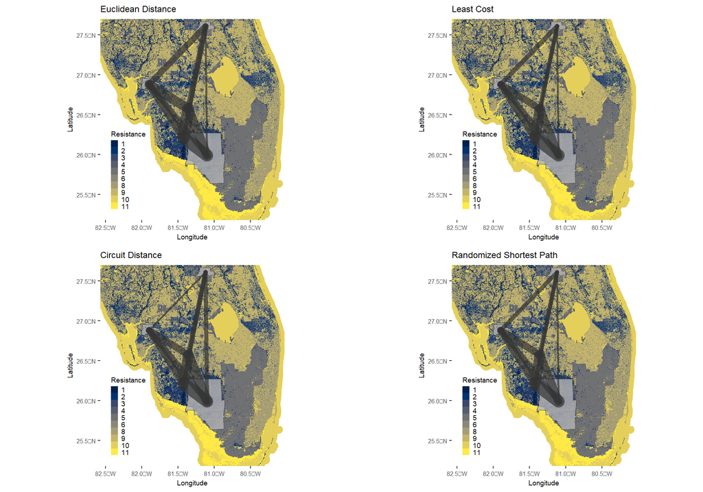

```r
plt_map_dist_fn <- function(mthd) {
  resistance_surface %>%
    as.data.frame(xy=T) %>%
    dplyr::rename(resistance=3) %>%
    dplyr::mutate(resistance=as.factor(resistance)) %>%
  ggplot(.) +
    geom_raster(mapping = aes(x=x, y=y, fill=resistance)) +
      geom_sf(data = public_lands, fill = "gray70", color = "gray30", alpha = 0.8) +
      geom_segment(
        data = all_dist_df %>% dplyr::filter(method == mthd)
        , mapping = aes(x = x1, y = y1, xend = x2, yend = y2, size = (1/distance_m2)) #
        , lineend = "round"
        , linejoin = "round"
        , color = "gray20"
        , alpha = 0.7
      ) +
      scale_fill_viridis_d(option = "cividis") +
      scale_x_continuous(expand = c(0, 0)) +
      scale_y_continuous(expand = c(0, 0)) +
      labs(
        subtitle = stringr::str_replace_all(mthd, "_", " ") %>% stringr::str_to_title()
        , x = "Longitude"
        , y = "Latitude"
        , fill = "Resistance"
      ) +
      theme_bw() +
      theme(
        legend.position = c(0.15, 0.25)
        , legend.key.size = unit(0.25, 'cm')
        , legend.text = element_text(size = 7)
        , legend.title = element_text(size = 7)
        , axis.title = element_text(size = 7)
        , axis.text.y = element_text(size=6)
        , axis.text.x = element_text(size=6)
        , panel.border = element_blank()
        , plot.subtitle = element_text(size=9)
        , panel.grid = element_blank()
      ) +
      guides(size = "none")
}
plt_list <- unique(all_dist_df$method) %>%
  purrr::map(plt_map_dist_fn)
cowplot::plot_grid(
  plotlist = plt_list
  , nrow = 2
)
```

### part b

Do you see any prominent differences among the methods? You can make a visual assessment. (1-2 sentences) (2 pts)

Based on visual inspection of the plot above, the most prominent differences occur between the Euclidean distance and Circuit distance methods.

### part c

Which conservation area pairing shows the greatest travel cost by least cost distance? Which conservation area pairing shows the least travel cost by circuit theory? Please provide the names of the parks. (2 pts)

```r
lcd_temp <- all_dist_df %>% dplyr::filter(method == "least_cost") %>%
  dplyr::arrange(desc(distance_m2)) %>%
  dplyr::filter(dplyr::row_number()==1) %>%
  dplyr::mutate(nm = paste0(maname1," & ", maname2) %>% stringr::str_to_title()) %>%
  dplyr::pull(nm)
circ_temp <- all_dist_df %>% dplyr::filter(method == "circuit_distance") %>%
  dplyr::arrange(distance_m2) %>%
  dplyr::filter(dplyr::row_number()==1) %>%
  dplyr::mutate(nm = paste0(maname1," & ", maname2) %>% stringr::str_to_title()) %>%
  dplyr::pull(nm)
```

The conservation area pairing that shows the *greatest* travel cost by least cost distance is **Kissimmee Prairie Preserve State Park & Big Cypress National Preserve**. The conservation area pairing that shows the *least* travel cost by circuit theory is **Florida Panther National Wildlife Refuge & Big Cypress National Preserve**

# Least-cost path & Least-cost corridor

## Question 6

Plot the least cost-path and least-cost corridor between Okaloacoochee Slough State Forest and Fred C. Babcock-Cecil M. Webb Wildlife Management Area using the lower 20% of accumulated cost cells. Include the outline of the conservation areas, the centroid points (of the conservation areas), and the resistance surface. Use ggplot to generate the plot. (8 pts)

### Data prep

```r
# filter polygons
public_lands_filter <- public_lands |>
  dplyr::filter(
    maname_ab %in% c("OKALOACOOCHEE SLOUGH SF", "BABCOCK-WEBB WMA")
  )
# filter resistance surface
resistance_surface_filter <- resistance_surface |>
  terra::crop(
    public_lands_filter |> sf::st_union() |> sf::st_buffer(1000)
  )
# create adjacency matrix aka transition matrix
  # this has to be done on a RasterLayer :(
transition_matrix <- gdistance::transition(
  1 / raster::raster(resistance_surface)
  , transitionFunction = mean
  , directions = 8
)
transition_matrix_filter <- gdistance::transition(
  1 / raster::raster(resistance_surface_filter)
  , transitionFunction = mean
  , directions = 8
)
# apply correction
transition_matrix <- gdistance::geoCorrection(transition_matrix, type="c", multpl=FALSE)
transition_matrix_filter <- gdistance::geoCorrection(transition_matrix_filter, type="c", multpl=FALSE)
#get least cost path
least_cost_path <- gdistance::shortestPath(
  transition_matrix
  , public_lands_filter |> dplyr::filter(dplyr::row_number()==1) |>
    sf::st_centroid() |> sf::st_coordinates()
  , public_lands_filter |> dplyr::filter(dplyr::row_number()==2) |>
    sf::st_centroid() |> sf::st_coordinates()
  , output="SpatialLines"
)
#get cumulative costs from each public land
cum_cost1 <- gdistance::accCost(transition_matrix_filter
  , public_lands_filter |> dplyr::filter(dplyr::row_number()==1) |>
    sf::st_centroid() |> sf::st_coordinates()
)
cum_cost2 <- gdistance::accCost(transition_matrix_filter
  , public_lands_filter |> dplyr::filter(dplyr::row_number()==2) |>
    sf::st_centroid() |> sf::st_coordinates()
)
#get least-cost corridor
  #Create a new Raster* object, based on two or more Raster* objects.
least_cost_corridor <- raster::overlay(
    cum_cost1
    , cum_cost2
    , fun=function(x, y){return(x + y)}
  ) |>
  terra::rast()

# get raster with only lowest 20% quantile cost cells
least_cost_corridor_q20 <- least_cost_corridor |>
  terra::clamp(
    lower = -Inf
    , upper = stats::quantile(least_cost_corridor, probs = 0.20, na.rm=TRUE)
    , values = FALSE
  ) |>
  terra::classify(rcl = (c(-Inf, Inf, 1) |> matrix(ncol=3, byrow=TRUE)))

if(FALSE){
  #plot
  plot(resistance_surface_filter, axes=F, box=F)
  plot(public_lands_filter, add=T)
  points(public_lands_filter |> sf::st_centroid() |> sf::st_coordinates(), col="grey20")
  lines(least_cost_path, col="red", lw=3)

  #plot
  plot(least_cost_corridor, legend=F, axes=F)
  plot(public_lands_filter, add=T)

}
```

### Plot: least-cost path & corridor

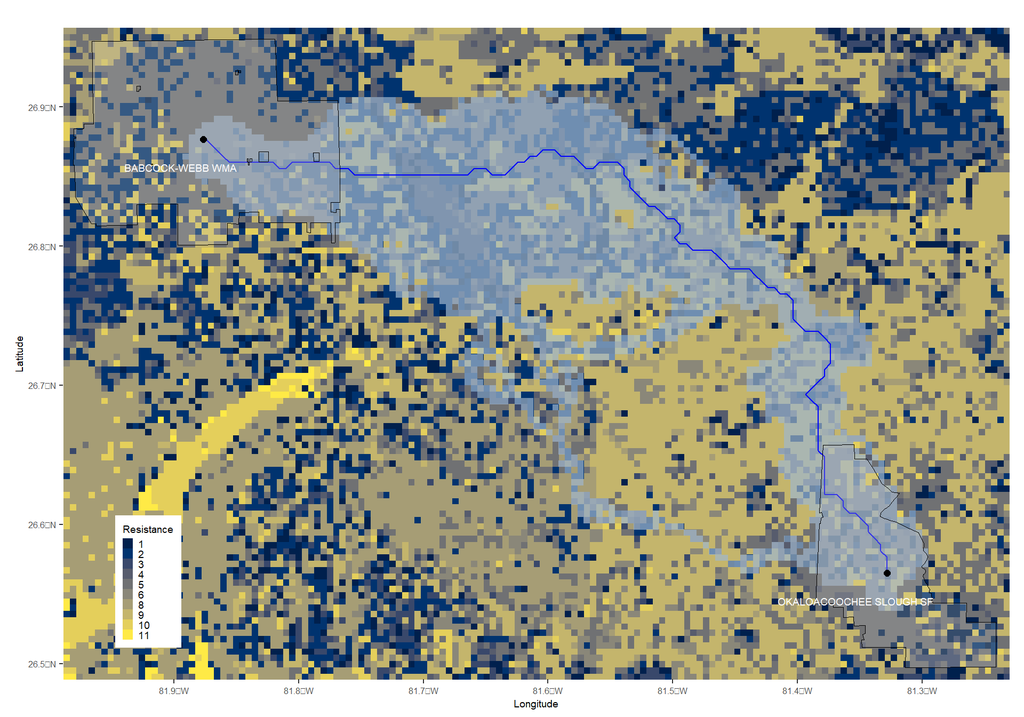

```r
# plot
ggplot()+
  geom_raster(
    data = resistance_surface_filter |>
        as.data.frame(xy=T) |>
        dplyr::rename(resistance=3)
    , mapping = aes(x=x, y=y, fill=as.factor(resistance))
  ) +
  geom_raster(
    data = least_cost_corridor_q20 |>
        as.data.frame(xy=T) |>
        dplyr::rename(corridor=3) |>
        dplyr::filter(!is.na(corridor))
    , mapping = aes(x=x, y=y)
    , fill = "slategray3"
    , alpha = 0.7
  ) +
  geom_sf(data = least_cost_path |> sf::st_as_sfc(), color = "blue", size = 4) +
  geom_sf(data = public_lands_filter, fill = "gray70", color = "black", alpha = 0.3) +
  geom_sf(data = public_lands_filter |> sf::st_centroid(), color = "black", size = 2) +
  geom_sf_text(
    data = public_lands_filter |> sf::st_centroid()
    , mapping = aes(label = maname_ab)
    , vjust = 4
    , hjust = 0.7
    , size = 2.5
    , color = "white"
  ) +

  scale_fill_viridis_d(option = "cividis") +
  scale_x_continuous(expand = c(0, 0)) +
  scale_y_continuous(expand = c(0, 0)) +
  labs(
    subtitle = ""
    , x = "Longitude"
    , y = "Latitude"
    , fill = "Resistance"
  ) +
  theme_bw() +
  theme(
    legend.position = c(0.09, 0.15)
    , legend.key.size = unit(0.25, 'cm')
    , legend.text = element_text(size = 7)
    , legend.title = element_text(size = 7)
    , axis.title = element_text(size = 7)
    , axis.text.y = element_text(size=6)
    , axis.text.x = element_text(size=6)
    , panel.border = element_blank()
    , plot.subtitle = element_text(size=9)
    , panel.grid = element_blank()
  ) +
  guides(size = "none")
```

The figure above shows the least cost-path and least-cost corridor (blue) between Okaloacoochee Slough State Forest and Fred C. Babcock-Cecil M. Webb Wildlife Management Area using the lower 20% of accumulated cost cells overlayed on the resistance surface for Florida panther movement.

### part a)

What is the dominant cover type in the corridor? (3.5 pts)

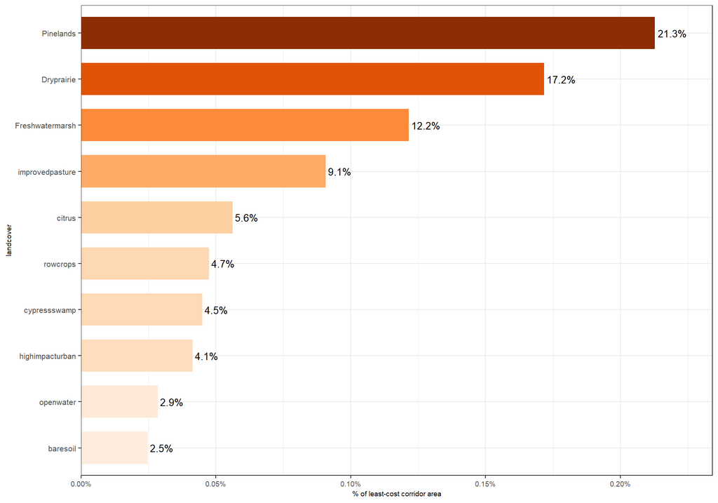

```r
landcov_corridor_temp <- landcov |>
  terra::mask(
    terra::as.polygons(least_cost_corridor_q20, trunc=TRUE, dissolve=TRUE, values=TRUE, na.rm=TRUE) |>
      sf::st_as_sf() |>
      sf::st_union() |>
      terra::vect()
  )
landcov_corridor_temp_freq <- landcov_corridor_temp |>
  terra::freq() |>
  dplyr::as_tibble() |>
  dplyr::left_join(
    resistance_reclass
    , by = c("value" = "landcover")
  ) |>
  dplyr::mutate(pct_area = count/sum(count,na.rm = T)) |>
  dplyr::arrange(desc(count)) |>
  dplyr::slice_head(n = 10)
# plot
ggplot(landcov_corridor_temp_freq, mapping = aes(y = reorder(description, pct_area), x = pct_area)) +
  geom_col(mapping = aes(fill=pct_area), width = 0.7) +
  geom_text(
    mapping = aes(label = pct_area |> scales::percent(accuracy=0.1))
    , color = "black", size = 3.5
    , hjust = -0.1
  ) +
  scale_fill_distiller(palette = "Oranges", direction = 1) +
  scale_x_continuous(expand = expansion(mult = c(0, .1)), labels = scales::percent_format(scale = 1)) +
  labs(
    x = "% of least-cost corridor area"
    , y = "landcover"
  ) +
  theme_bw() +
  theme(
    legend.position = "none"
    , axis.text = element_text(size=7)
    , axis.text.y = element_text(size=8)
    , axis.title = element_text(size=7)
  )
```

The figure above shows the dominant cover type in the least-cost corridor between Okaloacoochee Slough State Forest and Fred C. Babcock-Cecil M. Webb Wildlife Management Area using the lower 20% of accumulated cost cells. The dominant landcover type in the corridor is **Pinelands** which covers roughly **21.3%** of the corridor area.

### part b

What’s the Shannon diversity and evenness in the corridor? (3.5 pts)

```r
rbind(
    cbind(landscapemetrics::lsm_l_shdi(landcov_corridor_temp), metric_f = "Shannon's diversity index")
    , cbind(landscapemetrics::lsm_l_shei(landcov_corridor_temp), metric_f = "Shannon's evenness index")
  ) |>
  dplyr::select(
    metric_f,value
  ) |>
  kableExtra::kable(
      format = "html"
      , caption = "Shannon diversity and evenness in the corridor"
      , escape = FALSE
      , col.names = c(
        ""
        , "Value"
      )
      , digits = 2
    ) |>
    kable_styling(font_size = 14, full_width=F)
```

Shannon diversity and evenness in the corridor

|  | Value |
| --- | --- |
| Shannon’s diversity index | 2.56 |
| Shannon’s evenness index | 0.78 |

The table above shows the Shannon’s diversity index (**2.56**) and Shannon’s evenness index (**0.78**) in the least-cost corridor between Okaloacoochee Slough State Forest and Fred C. Babcock-Cecil M. Webb Wildlife Management Area using the lower 20% of accumulated cost cells.

# Flow mapping

## Question 7

Generate a four-panel plot (analogous to figure 9.10) using theta values of 0.000, 0.000001, 0.00001, and 0.001, but mapping probabilities between Okaloacoochee Slough State Forest and Fred C. Babcock-Cecil M. Webb Wildlife Management Area. What do the theta values signify? How do they influence connectivity measures? Use ggplot. (5 pts)

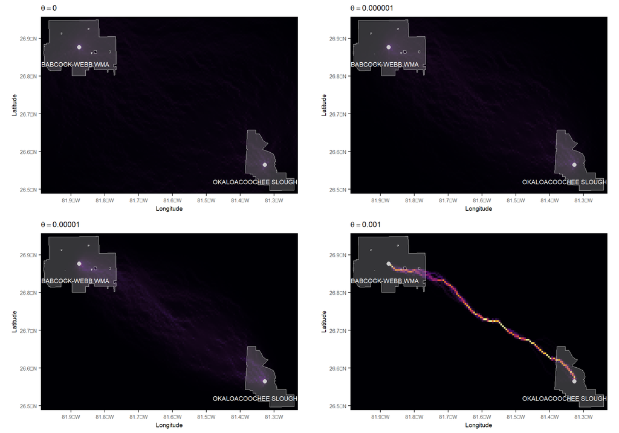

```r
# plot function()
plt_random_walk_fn <- function(theta_val) {
  #random walk (akin to a current map in Circuitscape)
  gdistance::passage(
      transition_matrix_filter
      , origin = public_lands_filter |>
          dplyr::filter(dplyr::row_number()==1) |>
          sf::st_centroid() |>
          sf::st_coordinates()
      , goal = public_lands_filter |>
          dplyr::filter(dplyr::row_number()==2) |>
          sf::st_centroid() |>
          sf::st_coordinates()
      , theta = theta_val
    ) |>
    terra::rast() |>
    as.data.frame(xy=T) |>
    rename(value = 3) |>
    dplyr::filter(!is.na(value)) |>
    # plot
    ggplot() +
      geom_raster(mapping = aes(x=x,y=y,fill=value)) +
      geom_sf(data = public_lands_filter, fill = "gray70", color = "gray80", alpha = 0.3) +
      geom_sf(data = public_lands_filter |> sf::st_centroid(), color = "gray80", size = 2) +
      geom_sf_text(
        data = public_lands_filter |> sf::st_centroid()
        , mapping = aes(label = maname_ab)
        , vjust = 4
        , hjust = 0.55
        , size = 2.5
        , color = "white"
      ) +

      scale_fill_viridis_c(option = "inferno") +
      scale_x_continuous(expand = c(0, 0)) +
      scale_y_continuous(expand = c(0, 0)) +
      labs(
        subtitle = bquote(theta==.(theta_val |> format(scientific = FALSE)))
        , x = "Longitude"
        , y = "Latitude"
      ) +
      theme_bw() +
      theme(
        legend.position = "none"
        , axis.title = element_text(size = 7)
        , axis.text.y = element_text(size=6)
        , axis.text.x = element_text(size=6)
        , panel.border = element_blank()
        , plot.subtitle = element_text(size=9)
        , panel.grid = element_blank()
      ) +
      guides(size = "none")
}
theta_vals <- c(0.000, 0.000001, 0.00001, 0.001)
plt_list_rw <- theta_vals |>
  purrr::map(plt_random_walk_fn)
cowplot::plot_grid(
  plotlist = plt_list_rw
  , nrow = 2
)
```

The figure above shows the probabilities of Florida panther passage based on randomized shortest paths between Okaloacoochee Slough State Forest and Fred C. Babcock-Cecil M. Webb Wildlife Management Area. Randomized shortest-path distance links the idea of least-cost paths and resistance distances as being along a continuum of movement possibilities by altering a parameter, $\theta$. When $\theta=0$, the model is equivalent to a circuit theory approach; as $\theta$ increases the model approaches the least-cost distance method.